[figure not shown]

# R Beginners Course

Introduction to R - Part 2

# Objective and contents

## Objective and contents

**Objective:** to generate the basic knowledge for importing, modifying, writing and plotting data as well as writing loops using the R Project for statistical computing.

**Contents:**

- Importing and exporting data
- Basic plots with R
- Relational operators
- Iterative processes

# Importing and exporting data

## Importing data

To import data to R we can use the *read.table* function, which returns a data frame object.

```r
read.table(file, header = FALSE, sep = "",
           dec = ".", row.names, col.names, na.strings = "NA",
           skip = 0, stringsAsFactors = FALSE, ...)
```

**file**: the name of the file which the data are going to be read from.

**header**: a logical value indicating whether the file contains the name of the variables as its first line.

**sep**: the field separator character. Values on each line of the file are separated by this character.

## Importing data

```r
read.table(file, header = FALSE, sep = "",
           dec = ".", row.names, col.names, na.strings = "NA",
           skip = 0, stringsAsFactors = FALSE, ...)
```

**dec**: the character used in the file for decimal points.

**na.strings**: a character vector of strings which are to be interpreted as NA values.

**stringsAsFactors**: [Logical] should character vectors be converted to factors?

Remember, if we don’t add one of these inputs, the default setting will be used.

## Importing data

Let’s create a table in Excel

[figure not shown]

## Importing data

Save the table as a csv file:

[figure not shown]

## Importing data

We use the path of the file in the read.table function.

```r
data.path <- "C:/Users/Example/Data.csv"
p_eta_table <- read.table(data.path, header = TRUE, sep = ",")
```

```r
print(p_eta_table)
##   Year Precipitation Evapotranspiration
## 1 2010          1250               1050
## 2 2011          1952               1748
## 3 2012          1328               1047
## 4 2013          1459               1284
## 5 2014          1642               1421
## 6 2015          1743               1484
## 7 2016          1238                998
## 8 2017          1432               1259
```

## Importing data

We could also use the read.csv function:

```r
p_eta_table <- read.csv(data.path)
```

```r
print(p_eta_table)
##   Year Precipitation Evapotranspiration
## 1 2010          1250               1050
## 2 2011          1952               1748
## 3 2012          1328               1047
## 4 2013          1459               1284
## 5 2014          1642               1421
## 6 2015          1743               1484
## 7 2016          1238                998
## 8 2017          1432               1259
```

## Read Table, CSV and CSV2 - Default Settings

The *read.table*, *read.csv* and *read.csv2* functions, can be used to import data. Note that the *read.csv* and *read.csv2* functions come from *read.table* but have different default settings.

```
             read.table     header = FALSE, sep = " "

             read.csv       header = TRUE, sep = ","

             read.csv2      header = TRUE, sep = ";"
```

## Working with data frames

*dim*: returns the number of rows and columns (i.e. the dimensions) of the object.

```r
dim(p_eta_table)
## [1] 8 3
```

Now we can add a new column to the existing data frame. As an example, we will calculate the values of precipitation minus evapotranspiration:

```r
p_eta_table$P_minus_ETa <- p_eta_table$Precipitation - p_eta_table$Evapotranspiration
```

## Working with data frames

```r
print(p_eta_table)
##   Year Precipitation Evapotranspiration P_minus_ETa
## 1 2010          1250               1050         200
## 2 2011          1952               1748         204
## 3 2012          1328               1047         281
## 4 2013          1459               1284         175
## 5 2014          1642               1421         221
## 6 2015          1743               1484         259
## 7 2016          1238                998         240
## 8 2017          1432               1259         173
```

## Working with data frames

Accessing data is the same for matrices and data frames. For example, to extract the value located in the second row and fourth column:

```r
p_eta_table[2, 4]
## [1] 204
```

Or:

```r
p_eta_table$P_minus_ETa[2]
## [1] 204
```

## Working with data frames

Also we can subset the first three values of the third row.

```r
p_eta_table[3, 1:3]
##   Year Precipitation Evapotranspiration
## 3 2012          1328               1047
```

Or make a subset of the data frame.

```r
p_eta_table[c(7, 2, 4), ]
##   Year Precipitation Evapotranspiration P_minus_ETa
## 7 2016          1238                998         240
## 2 2011          1952               1748         204
## 4 2013          1459               1284         175
```

## Export data

For exporting data, we can use the *write.table* function, which writes a data frame to a file or connection.

```r
write.table(x, file = "", append = FALSE, quote = TRUE, sep = " ",
            na = "NA", dec = ".", row.names = TRUE, ...)
```

**x**: the object to be written. Preferably a matrix or data frame.

**file**: the file path where we want to save the file (including file name and extension).

**append**: [Logical] only relevant if the file is a character string. If TRUE, the output is appended to the file. If FALSE, any existing file of the name is destroyed.

## Export data

```r
write.table(x, file = "", append = FALSE, quote = TRUE, sep = " ",
            na = "NA", dec = ".", row.names = TRUE, ...)
```

**quote**: [Logical] if TRUE, any character or factor columns will be surrounded by double quotes.

**sep**: the field separator string. Values within each row of x are separated by this string.

**na**: the string to use for missing values in the data.

## Export data

```r
write.table(x, file = "", append = FALSE, quote = TRUE, sep = " ",
            na = "NA", dec = ".", row.names = TRUE, ...)
```

**dec**: the string to use for decimal points in numeric or complex columns: must be a single character.

**row.names** and **col.names**: [Logical] indicating whether the names are to be written along with x, or a character vector of names to be written.

## Export data

Now, we will save the table that we have edited.

```r
write.table(p_eta_table, paste0(dirname(data.path), "/table_modified.csv"),
row.names = FALSE, sep = ",")
```

Now, you can go to the corresponding folder and check whether the file has been written.

## Export data

```r
saveRDS(p_eta_table, paste0(dirname(data.path), "/table_modified.rds"))
x <- readRDS(p_eta_table, paste0(dirname(data.path), "/table_modified.rds"))
```

## Joining tables

We can use the *bind* function to combine the rows from two separate tables to form one table. For this example, we will load tables with the most populous cities from both Spain and Italy.

```r
spain.pop <- read.csv("...add file path…/Cities/Spain.csv", header = TRUE)
italy.pop <- read.csv("...add file path…/Cities/Italy.csv", header = TRUE)
```

```
##                          City Population
## 1                      Madrid    3334730
## 2                   Barcelona    1664182
## 3                 Val\xe8ncia     800215
## 4                     Sevilla     691395
## 5                    Zaragoza     681877
## 6                   M\xe1laga     578460
## 7                      Murcia     459403
## 8                       Palma     422587
## 9  Las Palmas de Gran Canaria     381223
## 10                     Bilbao     350184
```

## Joining tables

First, let’s add information about the country to the table, so that the combined table will include the country for each entry.

```r
spain.pop$Country <- rep("Spain", times = nrow(spain.pop))
italy.pop$Country <- rep("Italy", times = nrow(italy.pop))
print(spain.pop)
##                          City Population Country
## 1                      Madrid    3334730   Spain
## 2                   Barcelona    1664182   Spain
## 3                 Val\xe8ncia     800215   Spain
## 4                     Sevilla     691395   Spain
## 5                    Zaragoza     681877   Spain
## 6                   M\xe1laga     578460   Spain
## 7                      Murcia     459403   Spain
## 8                       Palma     422587   Spain
## 9  Las Palmas de Gran Canaria     381223   Spain
## 10                     Bilbao     350184   Spain
print(italy.pop)
##      City Population Country
## 1    Roma    2808293   Italy
## 2  Milano    1406242   Italy
## 3  Napoli     948850   Italy
## 4  Torino     857910   Italy
## 5 Palermo     647422   Italy
## 6  Genova     565752   Italy
## 7 Bologna     395416   Italy
## 8 Firenze     366927   Italy
## 9    Bari     315284   Italy
```

## Joining tables

Now we can use the *rbind* function to join the tables.

```r
pop.table <- rbind(spain.pop, italy.pop)
```

Similarly, the *cbind* function will combine objects by columns.

# Basic plots with R

## Basic plots with R

The *plot* function is a generic function. This means that the type of plot produced is dependent on the type or class of the first argument.

```r
plot(x, y, type, main, sub, xlab, ylab)
```

**x**: the coordinates of points in the plot (x-axis) **y**: the coordinates of points in the plot (y-axis) **main**: a title for the plot **sub**: a subtitle for the plot **xlab** and **ylab**: titles for the x and y axes

Note: **y** can be omitted if **x** has the appropriate structure (e.g., for a raster file)

## Basic plots with R

To show the first set of plotting examples, we will read a csv file with World Bank data for annual mean cereal crop yield for both the world and for Germany.

```r
crop.yield <- read.csv("...add file path.../Data/Cereal_Yield.csv")
print(crop.yield)
```

[output not shown]

When we have a lot of data entries in stored in an object, we can use the *head* and *tail* functions to look at the first six and last six entries, respectively.

Note: the values presented are in kg/ha.

## Basic plots with R

```r
head(crop.yield)
##   Year Global_Cereal_Yield German_Cereal_Yield
## 1 1961            1431.537              2417.4
## 2 1962            1523.116              2962.2
## 3 1963            1589.004              2925.2
## 4 1964            1589.813              3120.8
## 5 1965            1639.062              2852.2
## 6 1966            1680.538              2878.0
tail(crop.yield)
##    Year Global_Cereal_Yield German_Cereal_Yield
## 52 2012            3619.562              6964.9
## 53 2013            3824.374              7318.0
## 54 2014            3892.360              8050.3
## 55 2015            3938.770              7497.8
## 56 2016            3967.029              7182.1
## 57 2017            4074.176              7269.9
```

## Line charts

Let’s start with a line chart for the global values.

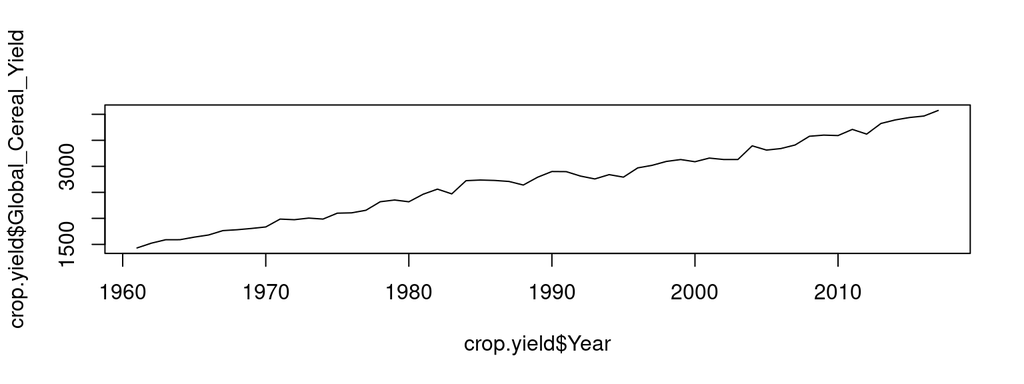

```r
plot(crop.yield$Year, crop.yield$Global_Cereal_Yield, type = "l")
```

Note: we will get the same result by selecting the column numbers instead of the names: i.e., plot(crop.yield[,1], crop.yield[,2], type = “l”).

## Line charts

Now, we will redo the plot in a more customised manner (chart title, axes titles, user defined minimum and maximum axis values).

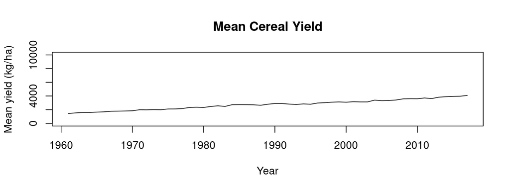

```r
plot(crop.yield$Year, crop.yield$Global_Cereal_Yield, type = "l",
main = "Mean Cereal Yield", xlab = "Year",
ylab = "Mean yield (kg/ha)", ylim = c(0, 10000))
```

## Line charts

The lines function is used to add another line to an existing plot. The legend function is used to add a legend to the plot.

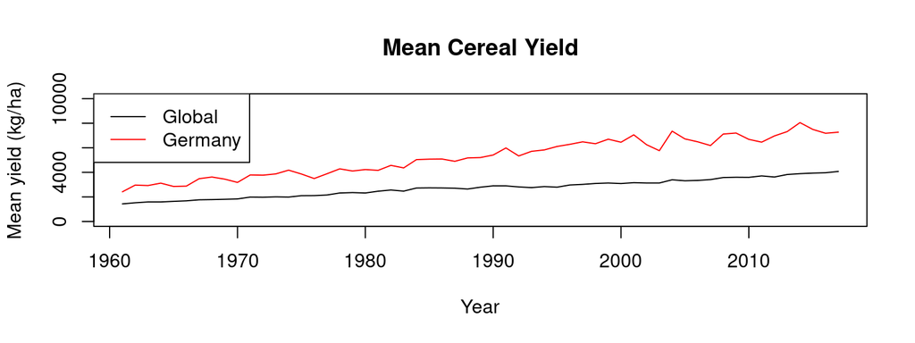

```r
lines(crop.yield$Year, crop.yield$German_Cereal_Yield, col = "red")
legend("topleft", c("Global", "Germany"), lty = 1, col = c("black", "red"))
```

## Adding Points to a Graph

The points function is used to add points to an existing plot. *pch* selects to the plotting character and *col* the plotting colour.

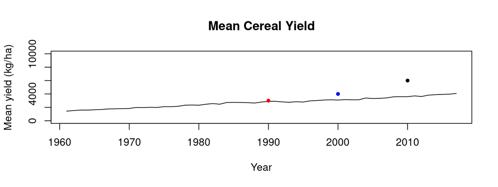

```r
points(x = c(1990, 2000, 2010), y = c(3000, 4000, 6000),
        pch = 20, col = c("red", "blue", "black"))
```

## Scatter Plots

Example: we can also plot the information using a scatter plot.

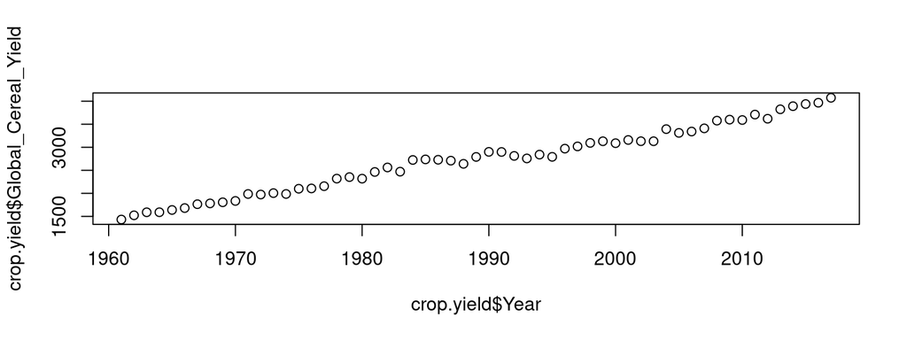

```r
plot(crop.yield$Year, crop.yield$Global_Cereal_Yield, type = "p")
```

Note: the default plot option is with points. Therefore, if we do not specify the type, we will have the same result.

## Histograms

A histogram is a graphical representation of the distribution of numerical data. - It is an estimate of the probability distribution of a continuous variable.

Example: the daily temperature values (in °C) for April in a particular city are:

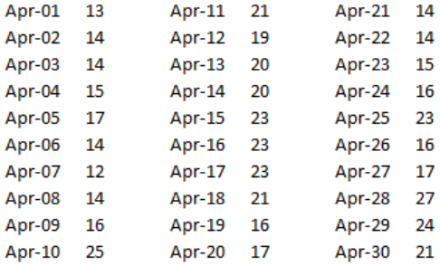

## Histograms

```r
temp <- c(13, 14, 14, 15, 17, 14, 12, 14, 16,
          25, 21, 19, 20, 20, 23, 23, 23, 21,
          16, 17, 14, 14, 15, 16, 23, 16, 17,
          27, 24, 21)
```

## Histograms

The function *hist* will generate a histogram.

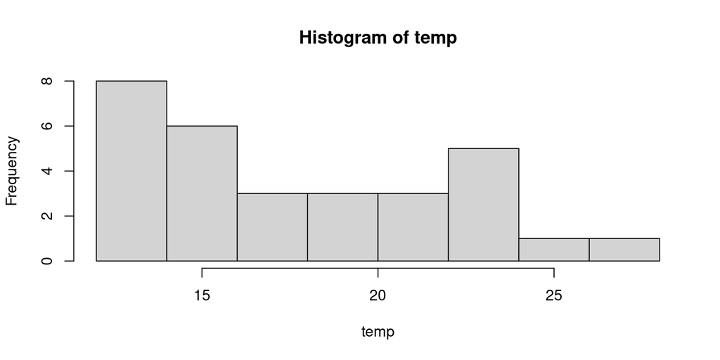

```r
hist(temp)
```

## Histograms

Again, we can customise the histogram.

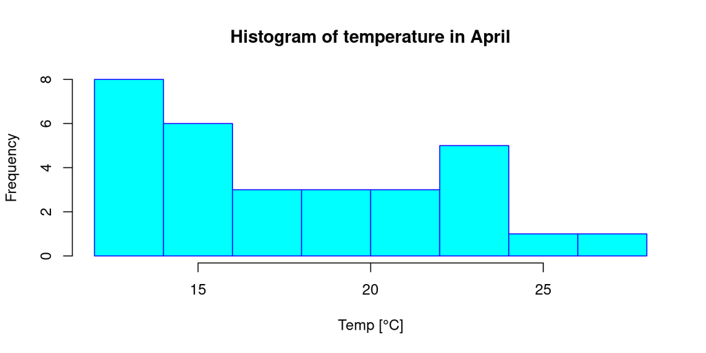

```r
hist(temp, main = "Histogram of temperature in April", xlab = "Temp [°C]",
border = "blue", col = "cyan", breaks = 8)
```

## Histograms

Remember to think carefully about how you plot and analyse your data - Looking at the previous example, if we plot the data with 5 breaks and with 8 breaks:

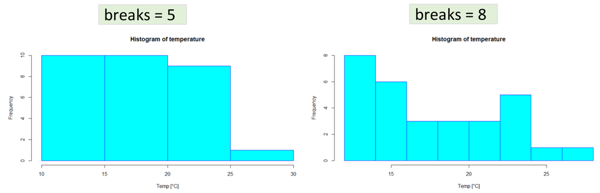

## Boxplots

The function *boxplot* produces box-and-whisker plot(s) of (grouped) values.

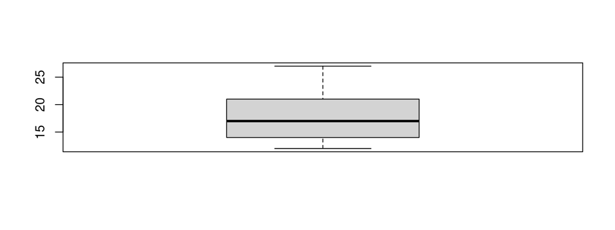

```r
boxplot(temp)
```

## Boxplots

Now, we will load daily values for maximum temperature in a pilot city.

```r
daily.temp <- read.csv("C:/Users/Data/Daily_Temp.csv")
```

```r
print(daily.temp)
##     Jan  Feb  Mar  Apr  May  Jun  Jul  Aug  Sep  Oct  Nov  Dec
## 1  15.0 17.8 20.6 32.2 27.2 22.8 32.2 31.1 30.0 30.6 24.4 17.2
## 2  15.6 16.7 18.3 22.8 29.4 22.8 32.2 33.9 29.4 31.1 28.9 17.2
## 3  12.8 16.1 20.0 21.1 35.0 26.1 32.2 32.8 28.3 27.2 25.6 16.7
## 4  17.8 18.9 23.3 27.2 32.8 23.3 31.7 32.8 31.7 19.4 15.6 17.2
## 5  21.7 21.7 27.8 24.4 30.0 25.6 33.9 30.0 27.8 17.2 17.8 17.8
## 6  21.1 25.0 20.0 19.4 25.6 22.8 34.4 29.4 36.7 18.9 14.4 18.3
## 7  16.1 26.7 15.0 16.7 22.2 23.3 32.8 29.4 37.8 22.8 17.8 19.4
## 8  15.0 17.2 21.1 14.4 20.0 22.2 31.1 29.4 37.8 27.2 21.1 19.4
## 9  15.0 21.1 28.9 14.4 17.2 21.1 30.6 27.2 27.8 28.9 25.6 21.1
## 10 17.8 20.6 26.7 20.0 21.7 21.1 29.4 26.7 23.9 28.3 23.9 21.7
## 11 21.1 23.3 23.9 22.2 22.8 23.3 27.8 26.7 26.7 28.3 25.0 15.6
## 12 22.8 26.7 19.4 21.7 25.6 22.8 25.0 26.7 29.4 38.3 17.8 11.7
## 13 23.9 23.9 21.1 18.9 24.4 25.6 25.0 25.6 27.8 37.2 22.8 12.2
## 14 27.2 19.4 25.0 23.3 20.0 27.2 23.3 28.3 25.6 31.1 21.7 16.1
## 15 26.7 19.4 25.6 30.0 17.8 27.2 24.4 28.9 25.6 27.2 20.6 15.0
## 16 27.2 16.1 24.4 33.3 18.9 25.6 25.0 30.0 22.2 26.1 21.7 17.8
## 17 28.9 16.1 22.8 27.8 17.2 23.9 26.7 31.1 24.4 29.4 21.7 19.4
## 18 28.9 18.9 20.6 18.3 17.2 25.0 28.9 30.0 27.2 26.7 15.6 14.4
## 19 20.6 14.4 17.2 20.6 20.6 24.4 30.6 27.2 27.2 22.8 16.1 14.4
## 20 24.4 13.9 15.6 20.0 22.2 27.8 31.1 27.8 27.8 23.9 16.1 17.8
## 21 25.0 16.1 15.6 20.0 25.6 32.2 30.6 26.7 28.3 22.8 16.1 18.3
## 22 22.2 16.1 16.7 20.6 21.1 30.6 27.8 29.4 30.6 28.9 19.4 18.9
## 23 24.4 15.6 19.4 20.6 20.0 29.4 28.9 31.1 28.3 28.9 17.8 20.0
## 24 23.9 15.6 16.7 20.0 22.8 27.8 28.3 31.7 25.0 21.7 16.7 22.8
## 25 23.3 15.0 16.7 22.2 26.1 29.4 33.3 33.3 23.3 20.0 18.9 23.3
## 26 25.0 11.7 15.6 22.8 23.3 29.4 30.0 35.0 26.7 21.1 27.8 23.3
## 27 25.0 13.9 18.9 28.3 26.7 31.7 26.1 36.1 30.0 24.4 28.9 21.1
## 28 24.4 18.9 18.3 28.3 22.2 28.3 27.8 33.3 27.8 27.2 27.2 26.1
## 29 20.6   NA 23.3 22.8 17.8 26.7 34.4 35.0 27.8 28.3 26.7 25.6
## 30 15.0   NA 29.4 26.7 26.1 28.9 36.7 32.2 31.1 31.1 23.3 22.8
## 31 17.2   NA 32.2   NA 26.1   NA 29.4 30.0   NA 28.9   NA 25.0
```

## Boxplots

To generate a *boxplot* with the data:

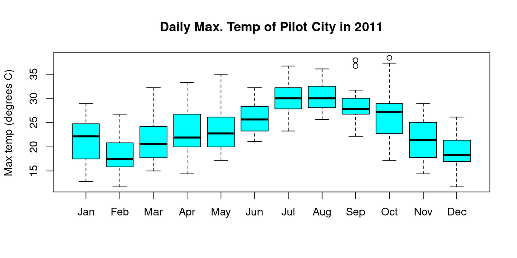

```r
boxplot(daily.temp, main = "Daily Max. Temp of Pilot City in 2011",
col = "cyan", ylab = "Max temp (degrees C)")
```

## Bar charts

The *barplot* function creates a bar chart with vertical or horizontal bars.

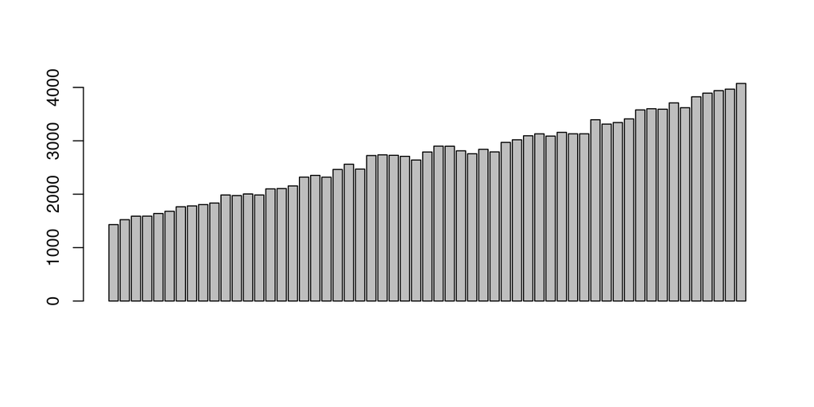

```r
barplot(crop.yield$Global_Cereal_Yield)
```

## Bar charts

Let’s customise the bar chart.

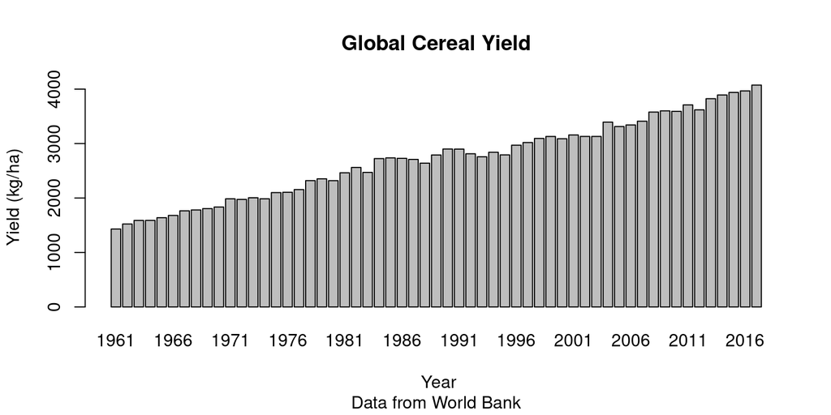

```r
barplot(crop.yield$Global_Cereal_Yield, main = "Global Cereal Yield",
sub = "Data from World Bank", xlab = " Year", ylab = "Yield (kg/ha)", names.arg = crop.yield$Year)
```

## Bar charts

Some other options to change how your data is presented in a bar chart:

- **col** to add colour to the plot
- **horiz** to create a horizontal bar chart (set to TRUE)

```r
x <- c(8, 5, 10)
barplot(x, main = "Example of Horizontal Bar Chart",
names.arg = c("A", "B", "C"), horiz = TRUE,
ylab = "number", col = c("red", "blue", "yellow"))
```

## Bar charts

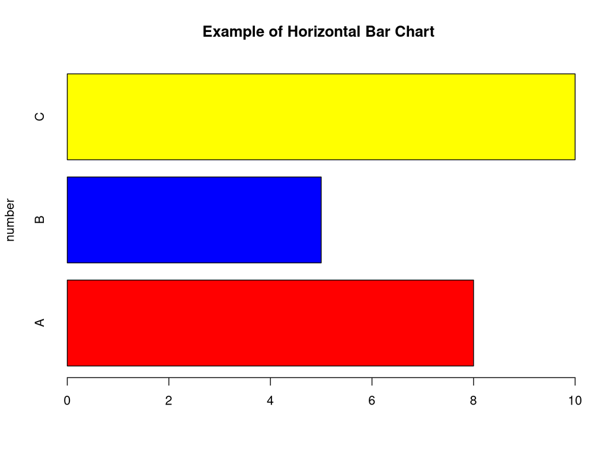

## Pie charts

The function pie draws a pie chart.

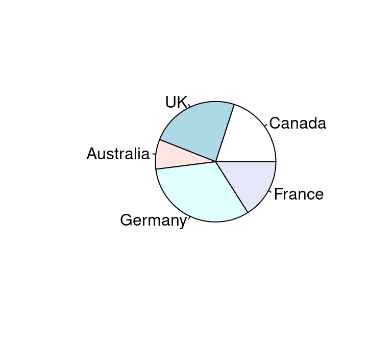

```r
slices <- c(10, 12, 4, 16, 8)
country <- c("Canada", "UK", "Australia", "Germany", "France")
pie(slices, labels = country)
```

## Pie charts

More personalised:

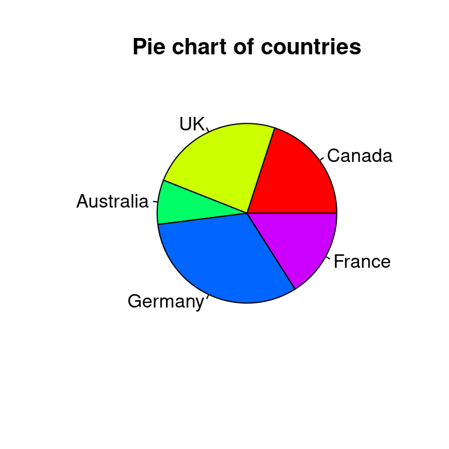

```r
pie(slices, labels = country, main = "Pie chart of countries",
col = rainbow(length(slices)))
```

# Relational operators

## Relational operators

R uses the following relational operators:

```
<     lower than
>     greater than
<=    lower than or equal to
>=    greater than or equal to
==    equal to
!=    not equal to
```

For example:

```r
5 > 4
## [1] TRUE
2 + 2 == 5
## [1] FALSE
```

# Iterative processes

## Iterative processes

Loops are very important because they allow us to do the following:

- Only run a certain code if a condition is met (if)
- Run the same process a specified number of times (for)
  - A common example is to run the same code for each time step
- Continue running a process until a condition is met (while)

# Iterative processes

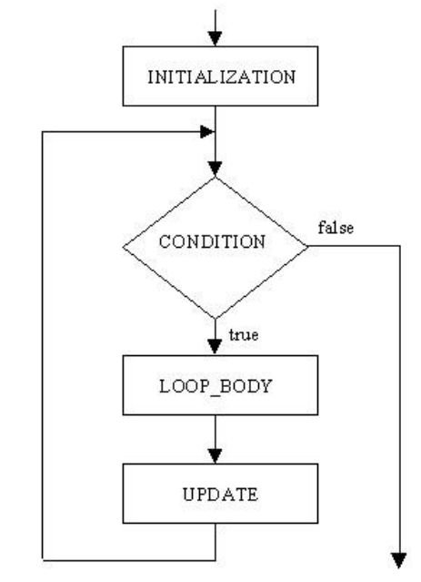

## If statements

R is able to perform conditional executions of the form:

```r
if (conditional statement)  process 1 else process 2
```

The conditional statement must evaluate a single logical value, the process 1 will be run if the condition is met, while the process 2 will run when the condition is not met.

## If statements

For example:

```r
if(5 > 4) print("Yes") else print("No")
## [1] "Yes"
```

Or:

```r
if(5 > 4)
  print("Yes") else
    print("No")
## [1] "Yes"
```

## If statements

If the processes contained in the condition require multiple lines, they should be written inside of curly brackets.

```r
if(5 > 4){
  x <- 5
  y <- x * 10
  print(y)
} else {
  x <- 2
  y <- x * 5
  print(y)

}
## [1] 50
```

## If statements

Note that the else statement is not always required:

```r
x <- 5
if(x > 4){
  y <- x *10
  print(y)
}
## [1] 50
```

## If statements

An example of an else clause within an if loop is as follows:

```r
input.value <- 32
if(input.value > 0){
  result <- log(input.value)
  paste("The log of", input.value, "is equal to", result)
} else {
  paste("Input value is negative, therefore no log value can be calculated")
}
## [1] "The log of 32 is equal to 3.46573590279973"
```

## If statements

Sometimes, we want to run a loop if any one of a set of conditions is met.

```r
day <- "Monday"

if(day == "Saturday" | day == "Sunday"){
  response <- paste("No alarm set for the weekend")
} else {
  alarm.time <- "7am"
  response <- paste("My alarm will be set for", alarm.time)
}

print(response)
## [1] "My alarm will be set for 7am"
```

## For loops

The *for* loop has the form:

```r
for(variable in vector) process
```

The variable will be iterated during the for loop taking each one of the values defined in the vector. The process will be applied in each iteration. For example:

```r
for(i in 1:5) print(i)
## [1] 1
## [1] 2
## [1] 3
## [1] 4
## [1] 5
```

## For loops

Similarly to the if statement, if the process has more than one line of code, it should be surrounded by curly brackets.

```r
for(i in 1:5){
  x <- i^2
  y <- x * 5
  print(y)
}
## [1] 5
## [1] 20
## [1] 45
## [1] 80
## [1] 125
```

## For loops

If you write a loop within a loop, we refer to this as a **nested loop**,

```r
for(i in 1:10){
  for (j in 1:5){
    a <- i + j
    cat(i, "plus", j, "is equal to", a, "\n")
}
  cat("------------------------ \n")
}
```

## For loops

We can use a *for* loop in a spatial time series analysis.

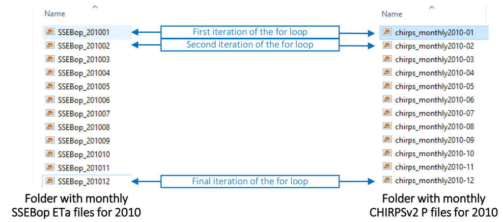

## While loops

The *while* loop has the form:

```r
while(condition) process
```

The condition will be evaluated, if it is true, the process will be run. When the condition is not longer met, the while loop will stop.

## While loops

For example:

```r
delta <- 0.75
x     <- 1
while(delta < x){
  x <- x - 0.05
  print(x)
}
## [1] 0.95
## [1] 0.9
## [1] 0.85
## [1] 0.8
## [1] 0.75
```